# Risk Factor Analysis

## Outcome Variable

**Outcome Variable:** wast_rec90d

## Predictor Variables

**Intervention Variable:** birthwt

**Adjustment Set:**

- arm
- sex
- W_mage
- meducyrs
- feducyrs
- hhwealth_quart
- vagbrth
- W_nrooms
- brthmon
- W_parity
- impfloor
- impsan
- safeh20
- delta_W_mage
- delta_meducyrs
- delta_feducyrs
- delta_hhwealth_quart
- delta_vagbrth
- delta_W_nrooms
- delta_brthmon
- delta_W_parity
- delta_impfloor
- delta_impsan
- delta_safeh20

## Stratifying Variables

The analysis was stratified on these variable(s):

- agecat
- studyid
- country

## Data Summary

| agecat | studyid | country | birthwt | wast_rec90d | n_cell | n |
| --- | --- | --- | --- | --- | --- | --- |
| 0-24 months | ki0047075b-MAL-ED | BANGLADESH | Normal or high birthweight | 0 | 31 | 119 |
| 0-24 months | ki0047075b-MAL-ED | BANGLADESH | Normal or high birthweight | 1 | 46 | 119 |
| 0-24 months | ki0047075b-MAL-ED | BANGLADESH | Low birth weight | 0 | 13 | 119 |
| 0-24 months | ki0047075b-MAL-ED | BANGLADESH | Low birth weight | 1 | 29 | 119 |
| 0-24 months | ki0047075b-MAL-ED | BRAZIL | Normal or high birthweight | 0 | 5 | 23 |
| 0-24 months | ki0047075b-MAL-ED | BRAZIL | Normal or high birthweight | 1 | 16 | 23 |
| 0-24 months | ki0047075b-MAL-ED | BRAZIL | Low birth weight | 0 | 1 | 23 |
| 0-24 months | ki0047075b-MAL-ED | BRAZIL | Low birth weight | 1 | 1 | 23 |
| 0-24 months | ki0047075b-MAL-ED | INDIA | Normal or high birthweight | 0 | 44 | 166 |
| 0-24 months | ki0047075b-MAL-ED | INDIA | Normal or high birthweight | 1 | 76 | 166 |
| 0-24 months | ki0047075b-MAL-ED | INDIA | Low birth weight | 0 | 21 | 166 |
| 0-24 months | ki0047075b-MAL-ED | INDIA | Low birth weight | 1 | 25 | 166 |
| 0-24 months | ki0047075b-MAL-ED | NEPAL | Normal or high birthweight | 0 | 12 | 85 |
| 0-24 months | ki0047075b-MAL-ED | NEPAL | Normal or high birthweight | 1 | 55 | 85 |
| 0-24 months | ki0047075b-MAL-ED | NEPAL | Low birth weight | 0 | 4 | 85 |
| 0-24 months | ki0047075b-MAL-ED | NEPAL | Low birth weight | 1 | 14 | 85 |
| 0-24 months | ki0047075b-MAL-ED | PERU | Normal or high birthweight | 0 | 3 | 34 |
| 0-24 months | ki0047075b-MAL-ED | PERU | Normal or high birthweight | 1 | 22 | 34 |
| 0-24 months | ki0047075b-MAL-ED | PERU | Low birth weight | 0 | 3 | 34 |
| 0-24 months | ki0047075b-MAL-ED | PERU | Low birth weight | 1 | 6 | 34 |
| 0-24 months | ki0047075b-MAL-ED | SOUTH AFRICA | Normal or high birthweight | 0 | 16 | 83 |
| 0-24 months | ki0047075b-MAL-ED | SOUTH AFRICA | Normal or high birthweight | 1 | 52 | 83 |
| 0-24 months | ki0047075b-MAL-ED | SOUTH AFRICA | Low birth weight | 0 | 1 | 83 |
| 0-24 months | ki0047075b-MAL-ED | SOUTH AFRICA | Low birth weight | 1 | 14 | 83 |
| 0-24 months | ki0047075b-MAL-ED | TANZANIA, UNITED REPUBLIC OF | Normal or high birthweight | 0 | 3 | 24 |
| 0-24 months | ki0047075b-MAL-ED | TANZANIA, UNITED REPUBLIC OF | Normal or high birthweight | 1 | 19 | 24 |
| 0-24 months | ki0047075b-MAL-ED | TANZANIA, UNITED REPUBLIC OF | Low birth weight | 0 | 0 | 24 |
| 0-24 months | ki0047075b-MAL-ED | TANZANIA, UNITED REPUBLIC OF | Low birth weight | 1 | 2 | 24 |
| 0-24 months | ki1000108-CMC-V-BCS-2002 | INDIA | Normal or high birthweight | 0 | 97 | 326 |
| 0-24 months | ki1000108-CMC-V-BCS-2002 | INDIA | Normal or high birthweight | 1 | 175 | 326 |

[output cut: 298 more lines]

The following strata were considered:

- agecat: 0-24 months, studyid: ki0047075b-MAL-ED, country: BANGLADESH
- agecat: 0-24 months, studyid: ki0047075b-MAL-ED, country: BRAZIL
- agecat: 0-24 months, studyid: ki0047075b-MAL-ED, country: INDIA
- agecat: 0-24 months, studyid: ki0047075b-MAL-ED, country: NEPAL
- agecat: 0-24 months, studyid: ki0047075b-MAL-ED, country: PERU
- agecat: 0-24 months, studyid: ki0047075b-MAL-ED, country: SOUTH AFRICA
- agecat: 0-24 months, studyid: ki0047075b-MAL-ED, country: TANZANIA, UNITED REPUBLIC OF
- agecat: 0-24 months, studyid: ki1000108-CMC-V-BCS-2002, country: INDIA
- agecat: 0-24 months, studyid: ki1000108-IRC, country: INDIA
- agecat: 0-24 months, studyid: ki1000109-EE, country: PAKISTAN
- agecat: 0-24 months, studyid: ki1000109-ResPak, country: PAKISTAN
- agecat: 0-24 months, studyid: ki1000304b-SAS-CompFeed, country: INDIA
- agecat: 0-24 months, studyid: ki1017093-NIH-Birth, country: BANGLADESH
- agecat: 0-24 months, studyid: ki1017093b-PROVIDE, country: BANGLADESH
- agecat: 0-24 months, studyid: ki1017093c-NIH-Crypto, country: BANGLADESH
- agecat: 0-24 months, studyid: ki1066203-TanzaniaChild2, country: TANZANIA, UNITED REPUBLIC OF
- agecat: 0-24 months, studyid: ki1101329-Keneba, country: GAMBIA
- agecat: 0-24 months, studyid: ki1114097-CMIN, country: BANGLADESH
- agecat: 0-24 months, studyid: ki1114097-CMIN, country: BRAZIL
- agecat: 0-24 months, studyid: ki1114097-CMIN, country: GUINEA-BISSAU
- agecat: 0-24 months, studyid: ki1114097-CMIN, country: PERU
- agecat: 0-24 months, studyid: ki1119695-PROBIT, country: BELARUS
- agecat: 0-24 months, studyid: ki1126311-ZVITAMBO, country: ZIMBABWE
- agecat: 0-24 months, studyid: ki1135781-COHORTS, country: GUATEMALA
- agecat: 0-24 months, studyid: ki1135781-COHORTS, country: INDIA
- agecat: 0-24 months, studyid: ki1135781-COHORTS, country: PHILIPPINES
- agecat: 0-24 months, studyid: kiGH5241-JiVitA-3, country: BANGLADESH
- agecat: 0-24 months, studyid: kiGH5241-JiVitA-4, country: BANGLADESH
- agecat: 0-6 months, studyid: ki0047075b-MAL-ED, country: BANGLADESH
- agecat: 0-6 months, studyid: ki0047075b-MAL-ED, country: BRAZIL
- agecat: 0-6 months, studyid: ki0047075b-MAL-ED, country: INDIA
- agecat: 0-6 months, studyid: ki0047075b-MAL-ED, country: NEPAL
- agecat: 0-6 months, studyid: ki0047075b-MAL-ED, country: PERU
- agecat: 0-6 months, studyid: ki0047075b-MAL-ED, country: SOUTH AFRICA
- agecat: 0-6 months, studyid: ki0047075b-MAL-ED, country: TANZANIA, UNITED REPUBLIC OF
- agecat: 0-6 months, studyid: ki1000108-CMC-V-BCS-2002, country: INDIA
- agecat: 0-6 months, studyid: ki1000108-IRC, country: INDIA
- agecat: 0-6 months, studyid: ki1000109-EE, country: PAKISTAN
- agecat: 0-6 months, studyid: ki1000109-ResPak, country: PAKISTAN
- agecat: 0-6 months, studyid: ki1000304b-SAS-CompFeed, country: INDIA
- agecat: 0-6 months, studyid: ki1017093-NIH-Birth, country: BANGLADESH
- agecat: 0-6 months, studyid: ki1017093b-PROVIDE, country: BANGLADESH
- agecat: 0-6 months, studyid: ki1017093c-NIH-Crypto, country: BANGLADESH
- agecat: 0-6 months, studyid: ki1066203-TanzaniaChild2, country: TANZANIA, UNITED REPUBLIC OF
- agecat: 0-6 months, studyid: ki1101329-Keneba, country: GAMBIA
- agecat: 0-6 months, studyid: ki1114097-CMIN, country: BANGLADESH
- agecat: 0-6 months, studyid: ki1114097-CMIN, country: BRAZIL
- agecat: 0-6 months, studyid: ki1114097-CMIN, country: GUINEA-BISSAU
- agecat: 0-6 months, studyid: ki1114097-CMIN, country: PERU
- agecat: 0-6 months, studyid: ki1119695-PROBIT, country: BELARUS
- agecat: 0-6 months, studyid: ki1126311-ZVITAMBO, country: ZIMBABWE
- agecat: 0-6 months, studyid: ki1135781-COHORTS, country: GUATEMALA
- agecat: 0-6 months, studyid: ki1135781-COHORTS, country: INDIA
- agecat: 0-6 months, studyid: ki1135781-COHORTS, country: PHILIPPINES
- agecat: 0-6 months, studyid: kiGH5241-JiVitA-3, country: BANGLADESH
- agecat: 0-6 months, studyid: kiGH5241-JiVitA-4, country: BANGLADESH
- agecat: 6-24 months, studyid: ki0047075b-MAL-ED, country: BANGLADESH
- agecat: 6-24 months, studyid: ki0047075b-MAL-ED, country: BRAZIL
- agecat: 6-24 months, studyid: ki0047075b-MAL-ED, country: INDIA
- agecat: 6-24 months, studyid: ki0047075b-MAL-ED, country: NEPAL
- agecat: 6-24 months, studyid: ki0047075b-MAL-ED, country: PERU
- agecat: 6-24 months, studyid: ki0047075b-MAL-ED, country: SOUTH AFRICA
- agecat: 6-24 months, studyid: ki0047075b-MAL-ED, country: TANZANIA, UNITED REPUBLIC OF
- agecat: 6-24 months, studyid: ki1000108-CMC-V-BCS-2002, country: INDIA
- agecat: 6-24 months, studyid: ki1000108-IRC, country: INDIA
- agecat: 6-24 months, studyid: ki1000109-EE, country: PAKISTAN
- agecat: 6-24 months, studyid: ki1000109-ResPak, country: PAKISTAN
- agecat: 6-24 months, studyid: ki1000304b-SAS-CompFeed, country: INDIA
- agecat: 6-24 months, studyid: ki1017093-NIH-Birth, country: BANGLADESH
- agecat: 6-24 months, studyid: ki1017093b-PROVIDE, country: BANGLADESH
- agecat: 6-24 months, studyid: ki1017093c-NIH-Crypto, country: BANGLADESH
- agecat: 6-24 months, studyid: ki1066203-TanzaniaChild2, country: TANZANIA, UNITED REPUBLIC OF
- agecat: 6-24 months, studyid: ki1101329-Keneba, country: GAMBIA
- agecat: 6-24 months, studyid: ki1114097-CMIN, country: BRAZIL
- agecat: 6-24 months, studyid: ki1114097-CMIN, country: PERU
- agecat: 6-24 months, studyid: ki1119695-PROBIT, country: BELARUS
- agecat: 6-24 months, studyid: ki1126311-ZVITAMBO, country: ZIMBABWE
- agecat: 6-24 months, studyid: ki1135781-COHORTS, country: GUATEMALA
- agecat: 6-24 months, studyid: ki1135781-COHORTS, country: INDIA
- agecat: 6-24 months, studyid: ki1135781-COHORTS, country: PHILIPPINES
- agecat: 6-24 months, studyid: kiGH5241-JiVitA-3, country: BANGLADESH
- agecat: 6-24 months, studyid: kiGH5241-JiVitA-4, country: BANGLADESH

### Dropped Strata

Some strata were dropped due to rare outcomes:

- agecat: 0-24 months, studyid: ki0047075b-MAL-ED, country: BRAZIL
- agecat: 0-24 months, studyid: ki0047075b-MAL-ED, country: NEPAL
- agecat: 0-24 months, studyid: ki0047075b-MAL-ED, country: PERU
- agecat: 0-24 months, studyid: ki0047075b-MAL-ED, country: SOUTH AFRICA
- agecat: 0-24 months, studyid: ki0047075b-MAL-ED, country: TANZANIA, UNITED REPUBLIC OF
- agecat: 0-24 months, studyid: ki1000109-ResPak, country: PAKISTAN
- agecat: 0-24 months, studyid: ki1114097-CMIN, country: BANGLADESH
- agecat: 0-24 months, studyid: ki1114097-CMIN, country: BRAZIL
- agecat: 0-24 months, studyid: ki1114097-CMIN, country: GUINEA-BISSAU
- agecat: 0-24 months, studyid: ki1114097-CMIN, country: PERU
- agecat: 0-24 months, studyid: ki1119695-PROBIT, country: BELARUS
- agecat: 0-6 months, studyid: ki0047075b-MAL-ED, country: BANGLADESH
- agecat: 0-6 months, studyid: ki0047075b-MAL-ED, country: BRAZIL
- agecat: 0-6 months, studyid: ki0047075b-MAL-ED, country: NEPAL
- agecat: 0-6 months, studyid: ki0047075b-MAL-ED, country: PERU
- agecat: 0-6 months, studyid: ki0047075b-MAL-ED, country: SOUTH AFRICA
- agecat: 0-6 months, studyid: ki0047075b-MAL-ED, country: TANZANIA, UNITED REPUBLIC OF
- agecat: 0-6 months, studyid: ki1000109-ResPak, country: PAKISTAN
- agecat: 0-6 months, studyid: ki1114097-CMIN, country: BANGLADESH
- agecat: 0-6 months, studyid: ki1114097-CMIN, country: BRAZIL
- agecat: 0-6 months, studyid: ki1114097-CMIN, country: GUINEA-BISSAU
- agecat: 0-6 months, studyid: ki1114097-CMIN, country: PERU
- agecat: 0-6 months, studyid: ki1119695-PROBIT, country: BELARUS
- agecat: 6-24 months, studyid: ki0047075b-MAL-ED, country: BRAZIL
- agecat: 6-24 months, studyid: ki0047075b-MAL-ED, country: NEPAL
- agecat: 6-24 months, studyid: ki0047075b-MAL-ED, country: PERU
- agecat: 6-24 months, studyid: ki0047075b-MAL-ED, country: SOUTH AFRICA
- agecat: 6-24 months, studyid: ki0047075b-MAL-ED, country: TANZANIA, UNITED REPUBLIC OF
- agecat: 6-24 months, studyid: ki1000109-ResPak, country: PAKISTAN
- agecat: 6-24 months, studyid: ki1017093c-NIH-Crypto, country: BANGLADESH
- agecat: 6-24 months, studyid: ki1114097-CMIN, country: BRAZIL
- agecat: 6-24 months, studyid: ki1114097-CMIN, country: PERU
- agecat: 6-24 months, studyid: ki1119695-PROBIT, country: BELARUS
- agecat: 6-24 months, studyid: ki1135781-COHORTS, country: GUATEMALA
- agecat: 6-24 months, studyid: ki1135781-COHORTS, country: INDIA
- agecat: 6-24 months, studyid: kiGH5241-JiVitA-3, country: BANGLADESH

## Methods Detail

We’re interested in the causal parameters $E[Y_a]$ for all values of $a \in \mathcal{A}$. These parameters represent the mean outcome if, possibly contrary to fact, we intervened to set all units to have $A=a$. Under the randomization and positivity assumptions, these are identified by the statistical parameters $\psi_a=E_W[E_{Y|A,W}(Y|A=a,W)]$. In addition, we’re interested in the mean of $Y$, $E[Y]$ under no intervention (the observed mean). We will estimate these parameters by using SuperLearner to fit the relevant likelihood factors – $E_{Y|A,W}(Y|A=a,W)$ and $p(A=a|W)$, and then updating our likelihood fit using a joint TMLE.

For unadjusted analyses ($W=\{\}$), initial likelihoods were estimated using Lrnr_glm to estimate the simple $E(Y|A)$ and Lrnr_mean to estimate $p(A)$. For adjusted analyses, a small library containing Lrnr_glmnet, Lrnr_xgboost, and Lrnr_mean was used.

Having estimated these parameters, we will then use the delta method to estimate relative risks and attributable risks relative to a prespecified baseline level of $A$.

# Results Detail

## Results Plots

[figure not shown]

[figure not shown]

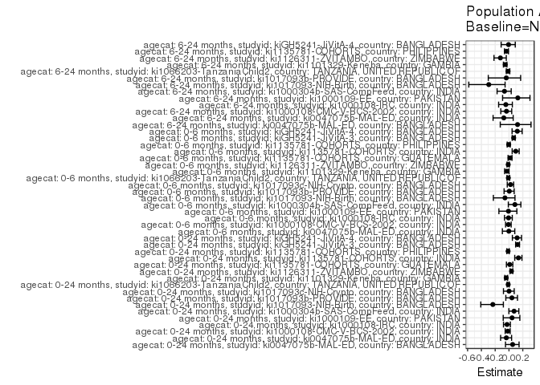

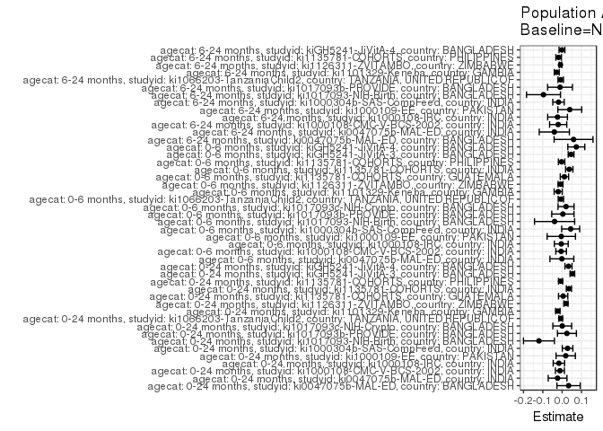

## Results Table

### Parameter: TSM

| agecat | studyid | country | intervention_level | baseline_level | estimate | ci_lower | ci_upper |
| --- | --- | --- | --- | --- | --- | --- | --- |
| 0-24 months | ki0047075b-MAL-ED | BANGLADESH | Normal or high birthweight | NA | 0.5969236 | 0.4762536 | 0.7175937 |
| 0-24 months | ki0047075b-MAL-ED | BANGLADESH | Low birth weight | NA | 0.6912565 | 0.5776290 | 0.8048841 |
| 0-24 months | ki0047075b-MAL-ED | INDIA | Normal or high birthweight | NA | 0.6320266 | 0.5347737 | 0.7292794 |
| 0-24 months | ki0047075b-MAL-ED | INDIA | Low birth weight | NA | 0.5465928 | 0.4043227 | 0.6888629 |
| 0-24 months | ki1000108-CMC-V-BCS-2002 | INDIA | Normal or high birthweight | NA | 0.6433824 | 0.5810822 | 0.7056825 |
| 0-24 months | ki1000108-CMC-V-BCS-2002 | INDIA | Low birth weight | NA | 0.5740741 | 0.4521081 | 0.6960401 |
| 0-24 months | ki1000108-IRC | INDIA | Normal or high birthweight | NA | 0.6056239 | 0.5450454 | 0.6662024 |
| 0-24 months | ki1000108-IRC | INDIA | Low birth weight | NA | 0.5706236 | 0.4814032 | 0.6598440 |
| 0-24 months | ki1000109-EE | PAKISTAN | Normal or high birthweight | NA | 0.3977813 | 0.3156248 | 0.4799379 |
| 0-24 months | ki1000109-EE | PAKISTAN | Low birth weight | NA | 0.4424788 | 0.3548178 | 0.5301397 |
| 0-24 months | ki1000304b-SAS-CompFeed | INDIA | Normal or high birthweight | NA | 0.3541211 | 0.3082400 | 0.4000022 |
| 0-24 months | ki1000304b-SAS-CompFeed | INDIA | Low birth weight | NA | 0.3992076 | 0.3474862 | 0.4509291 |
| 0-24 months | ki1017093-NIH-Birth | BANGLADESH | Normal or high birthweight | NA | 0.6316082 | 0.5218167 | 0.7413998 |
| 0-24 months | ki1017093-NIH-Birth | BANGLADESH | Low birth weight | NA | 0.5651787 | 0.4695243 | 0.6608332 |
| 0-24 months | ki1017093b-PROVIDE | BANGLADESH | Normal or high birthweight | NA | 0.5582652 | 0.4803461 | 0.6361842 |
| 0-24 months | ki1017093b-PROVIDE | BANGLADESH | Low birth weight | NA | 0.6130075 | 0.5365075 | 0.6895076 |
| 0-24 months | ki1017093c-NIH-Crypto | BANGLADESH | Normal or high birthweight | NA | 0.6231726 | 0.5440116 | 0.7023335 |
| 0-24 months | ki1017093c-NIH-Crypto | BANGLADESH | Low birth weight | NA | 0.6247722 | 0.5575063 | 0.6920381 |
| 0-24 months | ki1066203-TanzaniaChild2 | TANZANIA, UNITED REPUBLIC OF | Normal or high birthweight | NA | 0.6331728 | 0.5942315 | 0.6721141 |
| 0-24 months | ki1066203-TanzaniaChild2 | TANZANIA, UNITED REPUBLIC OF | Low birth weight | NA | 0.6777582 | 0.5369952 | 0.8185213 |
| 0-24 months | ki1101329-Keneba | GAMBIA | Normal or high birthweight | NA | 0.5743973 | 0.5422308 | 0.6065638 |
| 0-24 months | ki1101329-Keneba | GAMBIA | Low birth weight | NA | 0.2860771 | 0.2166222 | 0.3555320 |
| 0-24 months | ki1126311-ZVITAMBO | ZIMBABWE | Normal or high birthweight | NA | 0.5253120 | 0.5052723 | 0.5453517 |
| 0-24 months | ki1126311-ZVITAMBO | ZIMBABWE | Low birth weight | NA | 0.5970854 | 0.5694877 | 0.6246831 |
| 0-24 months | ki1135781-COHORTS | GUATEMALA | Normal or high birthweight | NA | 0.5102673 | 0.4501327 | 0.5704019 |
| 0-24 months | ki1135781-COHORTS | GUATEMALA | Low birth weight | NA | 0.5654159 | 0.4343532 | 0.6964786 |
| 0-24 months | ki1135781-COHORTS | INDIA | Normal or high birthweight | NA | 0.2208349 | 0.2000815 | 0.2415883 |
| 0-24 months | ki1135781-COHORTS | INDIA | Low birth weight | NA | 0.3215428 | 0.2932831 | 0.3498025 |
| 0-24 months | ki1135781-COHORTS | PHILIPPINES | Normal or high birthweight | NA | 0.6149844 | 0.5872258 | 0.6427429 |
| 0-24 months | ki1135781-COHORTS | PHILIPPINES | Low birth weight | NA | 0.5975268 | 0.5495373 | 0.6455164 |

[output cut: 62 more lines]

### Parameter: E(Y)

| agecat | studyid | country | intervention_level | baseline_level | estimate | ci_lower | ci_upper |
| --- | --- | --- | --- | --- | --- | --- | --- |
| 0-24 months | ki0047075b-MAL-ED | BANGLADESH | NA | NA | 0.6302521 | 0.5419905 | 0.7185137 |
| 0-24 months | ki0047075b-MAL-ED | INDIA | NA | NA | 0.6084337 | 0.5263180 | 0.6905495 |
| 0-24 months | ki1000108-CMC-V-BCS-2002 | INDIA | NA | NA | 0.6319018 | 0.5759256 | 0.6878781 |
| 0-24 months | ki1000108-IRC | INDIA | NA | NA | 0.5888325 | 0.5365454 | 0.6411196 |
| 0-24 months | ki1000109-EE | PAKISTAN | NA | NA | 0.4163424 | 0.3511349 | 0.4815500 |
| 0-24 months | ki1000304b-SAS-CompFeed | INDIA | NA | NA | 0.3822441 | 0.3470621 | 0.4174262 |
| 0-24 months | ki1017093-NIH-Birth | BANGLADESH | NA | NA | 0.5117647 | 0.4302715 | 0.5932579 |
| 0-24 months | ki1017093b-PROVIDE | BANGLADESH | NA | NA | 0.5830619 | 0.5262762 | 0.6398476 |
| 0-24 months | ki1017093c-NIH-Crypto | BANGLADESH | NA | NA | 0.6237942 | 0.5698223 | 0.6777662 |
| 0-24 months | ki1066203-TanzaniaChild2 | TANZANIA, UNITED REPUBLIC OF | NA | NA | 0.6258890 | 0.5879514 | 0.6638267 |
| 0-24 months | ki1101329-Keneba | GAMBIA | NA | NA | 0.5519802 | 0.5212828 | 0.5826776 |
| 0-24 months | ki1126311-ZVITAMBO | ZIMBABWE | NA | NA | 0.5451233 | 0.5286432 | 0.5616034 |
| 0-24 months | ki1135781-COHORTS | GUATEMALA | NA | NA | 0.5156250 | 0.4594779 | 0.5717721 |
| 0-24 months | ki1135781-COHORTS | INDIA | NA | NA | 0.2559618 | 0.2388022 | 0.2731215 |
| 0-24 months | ki1135781-COHORTS | PHILIPPINES | NA | NA | 0.6069712 | 0.5823178 | 0.6316245 |
| 0-24 months | kiGH5241-JiVitA-3 | BANGLADESH | NA | NA | 0.4229675 | 0.4118348 | 0.4341003 |
| 0-24 months | kiGH5241-JiVitA-4 | BANGLADESH | NA | NA | 0.2782438 | 0.2567862 | 0.2997015 |
| 0-6 months | ki0047075b-MAL-ED | INDIA | NA | NA | 0.6883117 | 0.5823564 | 0.7942670 |
| 0-6 months | ki1000108-CMC-V-BCS-2002 | INDIA | NA | NA | 0.6748768 | 0.6092233 | 0.7405304 |
| 0-6 months | ki1000108-IRC | INDIA | NA | NA | 0.6359833 | 0.5734338 | 0.6985327 |
| 0-6 months | ki1000109-EE | PAKISTAN | NA | NA | 0.5648148 | 0.4692893 | 0.6603404 |
| 0-6 months | ki1000304b-SAS-CompFeed | INDIA | NA | NA | 0.5147059 | 0.4610948 | 0.5683169 |
| 0-6 months | ki1017093-NIH-Birth | BANGLADESH | NA | NA | 0.6703297 | 0.5732092 | 0.7674502 |
| 0-6 months | ki1017093b-PROVIDE | BANGLADESH | NA | NA | 0.7880435 | 0.7295878 | 0.8464992 |
| 0-6 months | ki1017093c-NIH-Crypto | BANGLADESH | NA | NA | 0.8939394 | 0.8505280 | 0.9373508 |
| 0-6 months | ki1066203-TanzaniaChild2 | TANZANIA, UNITED REPUBLIC OF | NA | NA | 0.7014925 | 0.6517566 | 0.7512285 |
| 0-6 months | ki1101329-Keneba | GAMBIA | NA | NA | 0.6616766 | 0.6110579 | 0.7122953 |
| 0-6 months | ki1126311-ZVITAMBO | ZIMBABWE | NA | NA | 0.7439364 | 0.7268897 | 0.7609830 |
| 0-6 months | ki1135781-COHORTS | GUATEMALA | NA | NA | 0.7619048 | 0.7043195 | 0.8194900 |
| 0-6 months | ki1135781-COHORTS | INDIA | NA | NA | 0.3750728 | 0.3521661 | 0.3979795 |
| 0-6 months | ki1135781-COHORTS | PHILIPPINES | NA | NA | 0.7372654 | 0.7055895 | 0.7689413 |
| 0-6 months | kiGH5241-JiVitA-3 | BANGLADESH | NA | NA | 0.6760414 | 0.6627031 | 0.6893798 |
| 0-6 months | kiGH5241-JiVitA-4 | BANGLADESH | NA | NA | 0.6058824 | 0.5634305 | 0.6483342 |
| 6-24 months | ki0047075b-MAL-ED | BANGLADESH | NA | NA | 0.4745763 | 0.3430726 | 0.6060800 |
| 6-24 months | ki0047075b-MAL-ED | INDIA | NA | NA | 0.5393258 | 0.4214529 | 0.6571988 |
| 6-24 months | ki1000108-CMC-V-BCS-2002 | INDIA | NA | NA | 0.5609756 | 0.4682842 | 0.6536670 |
| 6-24 months | ki1000108-IRC | INDIA | NA | NA | 0.5161290 | 0.4322562 | 0.6000019 |
| 6-24 months | ki1000109-EE | PAKISTAN | NA | NA | 0.3087248 | 0.2336906 | 0.3837591 |
| 6-24 months | ki1000304b-SAS-CompFeed | INDIA | NA | NA | 0.2866242 | 0.2446853 | 0.3285631 |
| 6-24 months | ki1017093-NIH-Birth | BANGLADESH | NA | NA | 0.3291139 | 0.2187678 | 0.4394600 |
| 6-24 months | ki1017093b-PROVIDE | BANGLADESH | NA | NA | 0.2764228 | 0.1950773 | 0.3577682 |
| 6-24 months | ki1066203-TanzaniaChild2 | TANZANIA, UNITED REPUBLIC OF | NA | NA | 0.5570652 | 0.5044805 | 0.6096499 |
| 6-24 months | ki1101329-Keneba | GAMBIA | NA | NA | 0.5102506 | 0.4747348 | 0.5457664 |
| 6-24 months | ki1126311-ZVITAMBO | ZIMBABWE | NA | NA | 0.0702754 | 0.0549673 | 0.0855835 |
| 6-24 months | ki1135781-COHORTS | PHILIPPINES | NA | NA | 0.5010893 | 0.4669869 | 0.5351918 |
| 6-24 months | kiGH5241-JiVitA-4 | BANGLADESH | NA | NA | 0.1474961 | 0.1282628 | 0.1667294 |

### Parameter: RR

| agecat | studyid | country | intervention_level | baseline_level | estimate | ci_lower | ci_upper |
| --- | --- | --- | --- | --- | --- | --- | --- |
| 0-24 months | ki0047075b-MAL-ED | BANGLADESH | Normal or high birthweight | Normal or high birthweight | 1.0000000 | 1.0000000 | 1.0000000 |
| 0-24 months | ki0047075b-MAL-ED | BANGLADESH | Low birth weight | Normal or high birthweight | 1.1580318 | 0.8919883 | 1.5034252 |
| 0-24 months | ki0047075b-MAL-ED | INDIA | Normal or high birthweight | Normal or high birthweight | 1.0000000 | 1.0000000 | 1.0000000 |
| 0-24 months | ki0047075b-MAL-ED | INDIA | Low birth weight | Normal or high birthweight | 0.8648256 | 0.6409935 | 1.1668189 |
| 0-24 months | ki1000108-CMC-V-BCS-2002 | INDIA | Normal or high birthweight | Normal or high birthweight | 1.0000000 | 1.0000000 | 1.0000000 |
| 0-24 months | ki1000108-CMC-V-BCS-2002 | INDIA | Low birth weight | Normal or high birthweight | 0.8922751 | 0.7065214 | 1.1268660 |
| 0-24 months | ki1000108-IRC | INDIA | Normal or high birthweight | Normal or high birthweight | 1.0000000 | 1.0000000 | 1.0000000 |
| 0-24 months | ki1000108-IRC | INDIA | Low birth weight | Normal or high birthweight | 0.9422078 | 0.7826793 | 1.1342520 |
| 0-24 months | ki1000109-EE | PAKISTAN | Normal or high birthweight | Normal or high birthweight | 1.0000000 | 1.0000000 | 1.0000000 |
| 0-24 months | ki1000109-EE | PAKISTAN | Low birth weight | Normal or high birthweight | 1.1123668 | 0.8397799 | 1.4734335 |
| 0-24 months | ki1000304b-SAS-CompFeed | INDIA | Normal or high birthweight | Normal or high birthweight | 1.0000000 | 1.0000000 | 1.0000000 |
| 0-24 months | ki1000304b-SAS-CompFeed | INDIA | Low birth weight | Normal or high birthweight | 1.1273197 | 0.9392611 | 1.3530313 |
| 0-24 months | ki1017093-NIH-Birth | BANGLADESH | Normal or high birthweight | Normal or high birthweight | 1.0000000 | 1.0000000 | 1.0000000 |
| 0-24 months | ki1017093-NIH-Birth | BANGLADESH | Low birth weight | Normal or high birthweight | 0.8948248 | 0.6983684 | 1.1465459 |
| 0-24 months | ki1017093b-PROVIDE | BANGLADESH | Normal or high birthweight | Normal or high birthweight | 1.0000000 | 1.0000000 | 1.0000000 |
| 0-24 months | ki1017093b-PROVIDE | BANGLADESH | Low birth weight | Normal or high birthweight | 1.0980580 | 0.9138052 | 1.3194622 |
| 0-24 months | ki1017093c-NIH-Crypto | BANGLADESH | Normal or high birthweight | Normal or high birthweight | 1.0000000 | 1.0000000 | 1.0000000 |
| 0-24 months | ki1017093c-NIH-Crypto | BANGLADESH | Low birth weight | Normal or high birthweight | 1.0025669 | 0.8504809 | 1.1818495 |
| 0-24 months | ki1066203-TanzaniaChild2 | TANZANIA, UNITED REPUBLIC OF | Normal or high birthweight | Normal or high birthweight | 1.0000000 | 1.0000000 | 1.0000000 |
| 0-24 months | ki1066203-TanzaniaChild2 | TANZANIA, UNITED REPUBLIC OF | Low birth weight | Normal or high birthweight | 1.0704159 | 0.8620468 | 1.3291509 |
| 0-24 months | ki1101329-Keneba | GAMBIA | Normal or high birthweight | Normal or high birthweight | 1.0000000 | 1.0000000 | 1.0000000 |
| 0-24 months | ki1101329-Keneba | GAMBIA | Low birth weight | Normal or high birthweight | 0.4980475 | 0.3882519 | 0.6388927 |
| 0-24 months | ki1126311-ZVITAMBO | ZIMBABWE | Normal or high birthweight | Normal or high birthweight | 1.0000000 | 1.0000000 | 1.0000000 |
| 0-24 months | ki1126311-ZVITAMBO | ZIMBABWE | Low birth weight | Normal or high birthweight | 1.1366301 | 1.0705782 | 1.2067572 |
| 0-24 months | ki1135781-COHORTS | GUATEMALA | Normal or high birthweight | Normal or high birthweight | 1.0000000 | 1.0000000 | 1.0000000 |
| 0-24 months | ki1135781-COHORTS | GUATEMALA | Low birth weight | Normal or high birthweight | 1.1080778 | 0.8543198 | 1.4372093 |
| 0-24 months | ki1135781-COHORTS | INDIA | Normal or high birthweight | Normal or high birthweight | 1.0000000 | 1.0000000 | 1.0000000 |
| 0-24 months | ki1135781-COHORTS | INDIA | Low birth weight | Normal or high birthweight | 1.4560324 | 1.2810294 | 1.6549428 |
| 0-24 months | ki1135781-COHORTS | PHILIPPINES | Normal or high birthweight | Normal or high birthweight | 1.0000000 | 1.0000000 | 1.0000000 |
| 0-24 months | ki1135781-COHORTS | PHILIPPINES | Low birth weight | Normal or high birthweight | 0.9716130 | 0.8862776 | 1.0651649 |

[output cut: 62 more lines]

### Parameter: PAR

| agecat | studyid | country | intervention_level | baseline_level | estimate | ci_lower | ci_upper |
| --- | --- | --- | --- | --- | --- | --- | --- |
| 0-24 months | ki0047075b-MAL-ED | BANGLADESH | Normal or high birthweight | NA | 0.0333285 | -0.0270376 | 0.0936945 |
| 0-24 months | ki0047075b-MAL-ED | INDIA | Normal or high birthweight | NA | -0.0235928 | -0.0720899 | 0.0249042 |
| 0-24 months | ki1000108-CMC-V-BCS-2002 | INDIA | Normal or high birthweight | NA | -0.0114805 | -0.0345278 | 0.0115668 |
| 0-24 months | ki1000108-IRC | INDIA | Normal or high birthweight | NA | -0.0167914 | -0.0461034 | 0.0125205 |
| 0-24 months | ki1000109-EE | PAKISTAN | Normal or high birthweight | NA | 0.0185611 | -0.0313782 | 0.0685003 |
| 0-24 months | ki1000304b-SAS-CompFeed | INDIA | Normal or high birthweight | NA | 0.0281231 | 0.0008732 | 0.0553729 |
| 0-24 months | ki1017093-NIH-Birth | BANGLADESH | Normal or high birthweight | NA | -0.1198435 | -0.1997697 | -0.0399174 |
| 0-24 months | ki1017093b-PROVIDE | BANGLADESH | Normal or high birthweight | NA | 0.0247967 | -0.0241857 | 0.0737792 |
| 0-24 months | ki1017093c-NIH-Crypto | BANGLADESH | Normal or high birthweight | NA | 0.0006217 | -0.0478965 | 0.0491398 |
| 0-24 months | ki1066203-TanzaniaChild2 | TANZANIA, UNITED REPUBLIC OF | Normal or high birthweight | NA | -0.0072837 | -0.0169833 | 0.0024158 |
| 0-24 months | ki1101329-Keneba | GAMBIA | Normal or high birthweight | NA | -0.0224171 | -0.0338419 | -0.0109922 |
| 0-24 months | ki1126311-ZVITAMBO | ZIMBABWE | Normal or high birthweight | NA | 0.0198113 | 0.0089150 | 0.0307076 |
| 0-24 months | ki1135781-COHORTS | GUATEMALA | Normal or high birthweight | NA | 0.0053577 | -0.0185515 | 0.0292668 |
| 0-24 months | ki1135781-COHORTS | INDIA | Normal or high birthweight | NA | 0.0351269 | 0.0217477 | 0.0485062 |
| 0-24 months | ki1135781-COHORTS | PHILIPPINES | Normal or high birthweight | NA | -0.0080132 | -0.0187600 | 0.0027335 |
| 0-24 months | kiGH5241-JiVitA-3 | BANGLADESH | Normal or high birthweight | NA | 0.0528440 | 0.0409505 | 0.0647374 |
| 0-24 months | kiGH5241-JiVitA-4 | BANGLADESH | Normal or high birthweight | NA | 0.0328188 | 0.0145461 | 0.0510916 |
| 0-6 months | ki0047075b-MAL-ED | INDIA | Normal or high birthweight | NA | -0.0013435 | -0.0630803 | 0.0603933 |
| 0-6 months | ki1000108-CMC-V-BCS-2002 | INDIA | Normal or high birthweight | NA | -0.0053680 | -0.0327612 | 0.0220253 |
| 0-6 months | ki1000108-IRC | INDIA | Normal or high birthweight | NA | -0.0043914 | -0.0401212 | 0.0313384 |
| 0-6 months | ki1000109-EE | PAKISTAN | Normal or high birthweight | NA | -0.0042771 | -0.0775696 | 0.0690153 |
| 0-6 months | ki1000304b-SAS-CompFeed | INDIA | Normal or high birthweight | NA | 0.0441845 | -0.0023780 | 0.0907469 |
| 0-6 months | ki1017093-NIH-Birth | BANGLADESH | Normal or high birthweight | NA | -0.0390472 | -0.1428387 | 0.0647442 |
| 0-6 months | ki1017093b-PROVIDE | BANGLADESH | Normal or high birthweight | NA | 0.0037898 | -0.0537446 | 0.0613243 |
| 0-6 months | ki1017093c-NIH-Crypto | BANGLADESH | Normal or high birthweight | NA | 0.0201530 | -0.0212303 | 0.0615363 |
| 0-6 months | ki1066203-TanzaniaChild2 | TANZANIA, UNITED REPUBLIC OF | Normal or high birthweight | NA | -0.0064440 | -0.0201935 | 0.0073055 |
| 0-6 months | ki1101329-Keneba | GAMBIA | Normal or high birthweight | NA | -0.0202534 | -0.0412327 | 0.0007259 |
| 0-6 months | ki1126311-ZVITAMBO | ZIMBABWE | Normal or high birthweight | NA | -0.0083775 | -0.0211540 | 0.0043990 |
| 0-6 months | ki1135781-COHORTS | GUATEMALA | Normal or high birthweight | NA | 0.0119048 | -0.0096709 | 0.0334804 |
| 0-6 months | ki1135781-COHORTS | INDIA | Normal or high birthweight | NA | 0.0369069 | 0.0178855 | 0.0559283 |
| 0-6 months | ki1135781-COHORTS | PHILIPPINES | Normal or high birthweight | NA | -0.0027057 | -0.0192857 | 0.0138743 |
| 0-6 months | kiGH5241-JiVitA-3 | BANGLADESH | Normal or high birthweight | NA | 0.0462726 | 0.0313735 | 0.0611716 |
| 0-6 months | kiGH5241-JiVitA-4 | BANGLADESH | Normal or high birthweight | NA | 0.0732427 | 0.0293620 | 0.1171234 |
| 6-24 months | ki0047075b-MAL-ED | BANGLADESH | Normal or high birthweight | NA | 0.0590494 | -0.0413519 | 0.1594508 |
| 6-24 months | ki0047075b-MAL-ED | INDIA | Normal or high birthweight | NA | -0.0404508 | -0.1183636 | 0.0374620 |
| 6-24 months | ki1000108-CMC-V-BCS-2002 | INDIA | Normal or high birthweight | NA | -0.0204740 | -0.0647860 | 0.0238381 |
| 6-24 months | ki1000108-IRC | INDIA | Normal or high birthweight | NA | -0.0236940 | -0.0748046 | 0.0274167 |
| 6-24 months | ki1000109-EE | PAKISTAN | Normal or high birthweight | NA | 0.0396039 | -0.0220829 | 0.1012907 |
| 6-24 months | ki1000304b-SAS-CompFeed | INDIA | Normal or high birthweight | NA | -0.0186855 | -0.0480595 | 0.0106885 |
| 6-24 months | ki1017093-NIH-Birth | BANGLADESH | Normal or high birthweight | NA | -0.0964180 | -0.1841562 | -0.0086798 |
| 6-24 months | ki1017093b-PROVIDE | BANGLADESH | Normal or high birthweight | NA | -0.0109033 | -0.0750908 | 0.0532841 |
| 6-24 months | ki1066203-TanzaniaChild2 | TANZANIA, UNITED REPUBLIC OF | Normal or high birthweight | NA | -0.0074047 | -0.0214410 | 0.0066316 |
| 6-24 months | ki1101329-Keneba | GAMBIA | Normal or high birthweight | NA | -0.0279430 | -0.0407280 | -0.0151580 |
| 6-24 months | ki1126311-ZVITAMBO | ZIMBABWE | Normal or high birthweight | NA | -0.0087665 | -0.0152510 | -0.0022820 |
| 6-24 months | ki1135781-COHORTS | PHILIPPINES | Normal or high birthweight | NA | -0.0182120 | -0.0325402 | -0.0038838 |
| 6-24 months | kiGH5241-JiVitA-4 | BANGLADESH | Normal or high birthweight | NA | -0.0009116 | -0.0160120 | 0.0141889 |

### Parameter: PAF

| agecat | studyid | country | intervention_level | baseline_level | estimate | ci_lower | ci_upper |
| --- | --- | --- | --- | --- | --- | --- | --- |
| 0-24 months | ki0047075b-MAL-ED | BANGLADESH | Normal or high birthweight | NA | 0.0528812 | -0.0506008 | 0.1461704 |
| 0-24 months | ki0047075b-MAL-ED | INDIA | Normal or high birthweight | NA | -0.0387763 | -0.1215500 | 0.0378884 |
| 0-24 months | ki1000108-CMC-V-BCS-2002 | INDIA | Normal or high birthweight | NA | -0.0181682 | -0.0551987 | 0.0175628 |
| 0-24 months | ki1000108-IRC | INDIA | Normal or high birthweight | NA | -0.0285165 | -0.0795218 | 0.0200789 |
| 0-24 months | ki1000109-EE | PAKISTAN | Normal or high birthweight | NA | 0.0445813 | -0.0834556 | 0.1574874 |
| 0-24 months | ki1000304b-SAS-CompFeed | INDIA | Normal or high birthweight | NA | 0.0735736 | -0.0013494 | 0.1428906 |
| 0-24 months | ki1017093-NIH-Birth | BANGLADESH | Normal or high birthweight | NA | -0.2341770 | -0.4087279 | -0.0812542 |
| 0-24 months | ki1017093b-PROVIDE | BANGLADESH | Normal or high birthweight | NA | 0.0425285 | -0.0457503 | 0.1233551 |
| 0-24 months | ki1017093c-NIH-Crypto | BANGLADESH | Normal or high birthweight | NA | 0.0009966 | -0.0799084 | 0.0758403 |
| 0-24 months | ki1066203-TanzaniaChild2 | TANZANIA, UNITED REPUBLIC OF | Normal or high birthweight | NA | -0.0116374 | -0.0272867 | 0.0037734 |
| 0-24 months | ki1101329-Keneba | GAMBIA | Normal or high birthweight | NA | -0.0406121 | -0.0617669 | -0.0198788 |
| 0-24 months | ki1126311-ZVITAMBO | ZIMBABWE | Normal or high birthweight | NA | 0.0363428 | 0.0160794 | 0.0561889 |
| 0-24 months | ki1135781-COHORTS | GUATEMALA | Normal or high birthweight | NA | 0.0103906 | -0.0370489 | 0.0556600 |
| 0-24 months | ki1135781-COHORTS | INDIA | Normal or high birthweight | NA | 0.1372350 | 0.0833986 | 0.1879093 |
| 0-24 months | ki1135781-COHORTS | PHILIPPINES | Normal or high birthweight | NA | -0.0132020 | -0.0310227 | 0.0043107 |
| 0-24 months | kiGH5241-JiVitA-3 | BANGLADESH | Normal or high birthweight | NA | 0.1249363 | 0.0963046 | 0.1526608 |
| 0-24 months | kiGH5241-JiVitA-4 | BANGLADESH | Normal or high birthweight | NA | 0.1179499 | 0.0492255 | 0.1817068 |
| 0-6 months | ki0047075b-MAL-ED | INDIA | Normal or high birthweight | NA | -0.0019519 | -0.0957926 | 0.0838526 |
| 0-6 months | ki1000108-CMC-V-BCS-2002 | INDIA | Normal or high birthweight | NA | -0.0079540 | -0.0493890 | 0.0318449 |
| 0-6 months | ki1000108-IRC | INDIA | Normal or high birthweight | NA | -0.0069049 | -0.0646858 | 0.0477401 |
| 0-6 months | ki1000109-EE | PAKISTAN | Normal or high birthweight | NA | -0.0075726 | -0.1461008 | 0.1142118 |
| 0-6 months | ki1000304b-SAS-CompFeed | INDIA | Normal or high birthweight | NA | 0.0858441 | -0.0096910 | 0.1723398 |
| 0-6 months | ki1017093-NIH-Birth | BANGLADESH | Normal or high birthweight | NA | -0.0582508 | -0.2263297 | 0.0867915 |
| 0-6 months | ki1017093b-PROVIDE | BANGLADESH | Normal or high birthweight | NA | 0.0048092 | -0.0709471 | 0.0752066 |
| 0-6 months | ki1017093c-NIH-Crypto | BANGLADESH | Normal or high birthweight | NA | 0.0225440 | -0.0250709 | 0.0679472 |
| 0-6 months | ki1066203-TanzaniaChild2 | TANZANIA, UNITED REPUBLIC OF | Normal or high birthweight | NA | -0.0091861 | -0.0290217 | 0.0102672 |
| 0-6 months | ki1101329-Keneba | GAMBIA | Normal or high birthweight | NA | -0.0306092 | -0.0630675 | 0.0008582 |
| 0-6 months | ki1126311-ZVITAMBO | ZIMBABWE | Normal or high birthweight | NA | -0.0112611 | -0.0285936 | 0.0057794 |
| 0-6 months | ki1135781-COHORTS | GUATEMALA | Normal or high birthweight | NA | 0.0156250 | -0.0132322 | 0.0436603 |
| 0-6 months | ki1135781-COHORTS | INDIA | Normal or high birthweight | NA | 0.0983993 | 0.0462344 | 0.1477111 |
| 0-6 months | ki1135781-COHORTS | PHILIPPINES | Normal or high birthweight | NA | -0.0036699 | -0.0264152 | 0.0185713 |
| 0-6 months | kiGH5241-JiVitA-3 | BANGLADESH | Normal or high birthweight | NA | 0.0684464 | 0.0460512 | 0.0903158 |
| 0-6 months | kiGH5241-JiVitA-4 | BANGLADESH | Normal or high birthweight | NA | 0.1208860 | 0.0448476 | 0.1908711 |
| 6-24 months | ki0047075b-MAL-ED | BANGLADESH | Normal or high birthweight | NA | 0.1244256 | -0.1265584 | 0.3194933 |
| 6-24 months | ki0047075b-MAL-ED | INDIA | Normal or high birthweight | NA | -0.0750025 | -0.2305405 | 0.0608758 |
| 6-24 months | ki1000108-CMC-V-BCS-2002 | INDIA | Normal or high birthweight | NA | -0.0364971 | -0.1189192 | 0.0398537 |
| 6-24 months | ki1000108-IRC | INDIA | Normal or high birthweight | NA | -0.0459071 | -0.1500380 | 0.0487952 |
| 6-24 months | ki1000109-EE | PAKISTAN | Normal or high birthweight | NA | 0.1282822 | -0.0923908 | 0.3043772 |
| 6-24 months | ki1000304b-SAS-CompFeed | INDIA | Normal or high birthweight | NA | -0.0651917 | -0.1724805 | 0.0322796 |
| 6-24 months | ki1017093-NIH-Birth | BANGLADESH | Normal or high birthweight | NA | -0.2929624 | -0.5824394 | -0.0564396 |
| 6-24 months | ki1017093b-PROVIDE | BANGLADESH | Normal or high birthweight | NA | -0.0394445 | -0.3002018 | 0.1690176 |
| 6-24 months | ki1066203-TanzaniaChild2 | TANZANIA, UNITED REPUBLIC OF | Normal or high birthweight | NA | -0.0132923 | -0.0389212 | 0.0117043 |
| 6-24 months | ki1101329-Keneba | GAMBIA | Normal or high birthweight | NA | -0.0547633 | -0.0806312 | -0.0295145 |
| 6-24 months | ki1126311-ZVITAMBO | ZIMBABWE | Normal or high birthweight | NA | -0.1247451 | -0.2174589 | -0.0390918 |
| 6-24 months | ki1135781-COHORTS | PHILIPPINES | Normal or high birthweight | NA | -0.0363448 | -0.0654709 | -0.0080149 |
| 6-24 months | kiGH5241-JiVitA-4 | BANGLADESH | Normal or high birthweight | NA | -0.0061802 | -0.1139159 | 0.0911355 |